# Land Cover Classification of the Cache la Poudre River Watershed in Northern Colorado

Max Warnock | February 2026

This project uses satellite imagery and k-means clustering to map differences in land cover across the Cache la Poudre River watershed, an important water source for Northern Colorado that was affected by major wildfires in 2020.

**Full analysis:** the complete notebook, with all of the code, is available here: [Land Cover Classification of the Cache la Poudre River Watershed](https://maxwarnock.github.io/projects/clustering-portfolio-post.html)

## Introduction

The Cache la Poudre River watershed is a vital water resource for several cities in Northern Colorado, including Fort Collins, Greeley, Timnath, and Windsor. In an average year, it provides approximately 274,000 acre-feet of water and supplies water for more than 400,000 residents [(Cache la Poudre River Watershed. CPRW)](https://www.poudrewatershed.org/cache-la-poudre-watershed). The Poudre is also Colorado's only Wild and Scenic River [(Cache la Poudre River. National Wild and Scenic Rivers System)](https://rivers.gov/river/cache-la-poudre).

[figure not shown]

*Image Source: [Visit Fort Collins. Photo: Richard Haro.](https://www.visitftcollins.com/things-to-do/parks-open-spaces/cache-la-poudre-river/)*

In 2020, the Cameron Peak Fire and the East Troublesome Fire became the two largest wildfires in Colorado's recorded history [(Fire History. NPS)](https://www.nps.gov/romo/learn/fire-history.htm), burning a combined total of roughly 400,000 acres. The Cameron Peak Fire started in the upper Poudre River watershed and burned 208,913 acres across the Poudre, Big Thompson, and Laramie watersheds [(Cameron Peak Fire. CPRW)](https://www.poudrewatershed.org/cameronpeakfire). The East Troublesome Fire burned 193,812 acres to the southwest, mostly in Grand County [(East Troublesome Fire. Wikipedia)](https://en.wikipedia.org/wiki/East_Troublesome_Fire). Intense wildfires like these remove canopy cover, trees, and roots, which can drastically change the landscape and greatly increase the risk of flooding and erosion [(Cameron Peak Post-Fire Impacts. CPRW)](https://www.poudrewatershed.org/blog/cameron-peak-post-fire-impacts).

Because the landscape of the watershed is changing, I wanted to map its different land cover types. In this project, I used satellite imagery and a k-means unsupervised clustering algorithm to create a land cover classification map. This method doesn't tell us what each class represents, but it groups together areas with similar spectral signatures to show differences between land features. Maps like this are a starting point for tracking land cover change over time, including impacts from wildfires.

## Study Area

I selected the watershed using the U.S. Geological Survey's Watershed Boundary Dataset [(Hydrologic Units. USGS)](https://water.usgs.gov/themes/hydrologic-units/). The Poudre watershed (subbasin code 10190007) covers about 1.2 million acres (4,896 square kilometers) in Colorado and Wyoming. The western half of the watershed collects runoff from the eastern slope of the Rocky Mountains, while the eastern half extends onto the plains, with farmland and the developed areas around Fort Collins and Greeley.

[figure not shown]

*The Cache la Poudre River watershed (shaded white) over [Esri World Imagery](https://www.arcgis.com/home/item.html?id=10df2279f9684e4a9f6a7f08febac2a9).*

## Data

| Data | Source | Used for |
| --- | --- | --- |
| Satellite imagery | [Harmonized Landsat Sentinel-2 (HLS), HLSL30 v2.0](https://doi.org/10.5067/HLS/HLSL30.002) | 30 m surface reflectance from Landsat 8/9, June-August 2024 |
| Watershed boundary | [USGS Watershed Boundary Dataset (WBD)](https://water.usgs.gov/themes/hydrologic-units/) | Outline of the Poudre watershed |
| Data access | [NASA Earthdata](https://www.earthdata.nasa.gov/) and the earthaccess library | Searching for and streaming the HLS files |
| Basemap | [Esri World Imagery](https://www.arcgis.com/home/item.html?id=10df2279f9684e4a9f6a7f08febac2a9) | Background for the site map |

## Methods

Preparing the satellite data took the most work. The HLS images come as tiles (granules), so for each granule I cropped the data to the watershed's bounding box and removed pixels flagged as cloud, cloud shadow, or adjacent to clouds, using the quality band that comes with the data [(HLS User Guide. NASA)](https://lpdaac.usgs.gov/documents/1698/HLS_User_Guide_V2.pdf). I then merged the granules from each date and took the median value of each pixel across all of the dates from June through August 2024. This produced one cloud-free composite image for each spectral band.

Next, I used k-means clustering from scikit-learn ([Pedregosa et al., 2011](https://www.jmlr.org/papers/v12/pedregosa11a.html)) to group the pixels. K-means is an unsupervised algorithm, meaning it doesn't need labeled training data. It sorts pixels into a chosen number of clusters so that pixels in the same cluster have similar spectral signatures [(K-means. scikit-learn)](https://scikit-learn.org/stable/modules/clustering.html#k-means). Because the study area is so large, I found that 6 clusters gave the best differentiation between land cover features.

## Results

The maps below compare a true-color (red, green, blue) image of the study area with the k-means classification.

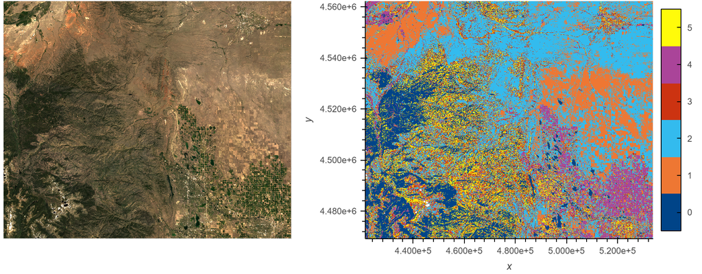

*True-color image of the study area (left) and the six k-means land cover classes (right). The class numbers are arbitrary and do not correspond to specific land cover types.*

The k-means algorithm successfully differentiated between many land cover features. Water bodies (dark blue) are clearly outlined, especially on the plains on the eastern side. However, the algorithm also grouped water with shadows and darker forested areas in the mountains on the western side of the map. Urban/developed areas were also grouped with some of the more arid mountain regions. These are different land features, but their spectral signatures are very similar. The algorithm did well at identifying farmland and very "green" areas, such as the crop circles highlighted in purple in the southeast. As humans, it's easier for us to tell these features apart based on their location, shape, and recognizable characteristics, but the k-means algorithm only considers each pixel's spectral values. The map also covers the watershed's full rectangular bounding box, so it includes some land outside the watershed boundary.

## Conclusion

This project shows how freely available satellite data and Python libraries can be used to map differences in land cover across a large watershed. Most of the work was data preparation, including downloading, cropping, cloud masking, merging, and compositing the imagery. The k-means map correctly separated many features, but some classes combined unrelated features with similar spectral signatures, such as water and shadows.

I was interested in this watershed because of the 2020 wildfires. A next step would be to create k-means maps for years before the fires and compare them to recent years. Change detection methods, such as the approach of [Lv et al. (2019)](https://doi.org/10.1109/ACCESS.2019.2892648), which applies k-means clustering to the differences between images from two dates, could then identify where the land cover changed.

## Additional Resources

The full project repository, with the notebook and figures, is available on GitHub:

**github.com/maxwarnock/Landcover_Classification_Poudre**

The full analysis, with all of the code and figures, is available here:

**[Full analysis: Land Cover Classification of the Cache la Poudre River Watershed](https://maxwarnock.github.io/projects/clustering-portfolio-post.html)**

## References

Coalition for the Poudre River Watershed. Cache la Poudre River Watershed. https://www.poudrewatershed.org/cache-la-poudre-watershed

Coalition for the Poudre River Watershed. Cameron Peak Fire. https://www.poudrewatershed.org/cameronpeakfire

Coalition for the Poudre River Watershed. Cameron Peak Post-Fire Impacts - Debris Flow, Flooding & Water Quality. https://www.poudrewatershed.org/blog/cameron-peak-post-fire-impacts

earthaccess contributors. earthaccess. National Snow and Ice Data Center (NSIDC). https://github.com/nsidc/earthaccess

Esri. World Imagery. https://www.arcgis.com/home/item.html?id=10df2279f9684e4a9f6a7f08febac2a9

Ju, J., Neigh, C., Sridhar, M., Claverie, M., Skakun, S., Roger, J.-C., Vermote, E., Dungan, J., & Ashokkumar, L. Harmonized Landsat and Sentinel-2 (HLS) Product User Guide, Product Version 2.0. NASA. https://lpdaac.usgs.gov/documents/1698/HLS_User_Guide_V2.pdf

Lv, Z., Liu, T., Shi, C., Benediktsson, J. A., & Du, H. (2019). Novel Land Cover Change Detection Method Based on k-Means Clustering and Adaptive Majority Voting Using Bitemporal Remote Sensing Images. IEEE Access, 7, 34425-34437. https://doi.org/10.1109/ACCESS.2019.2892648

Masek, J., Ju, J., Roger, J.-C., Skakun, S., Vermote, E., Claverie, M., Dungan, J., Yin, Z., Freitag, B., & Justice, C. (2021). HLS Operational Land Imager Surface Reflectance and TOA Brightness Daily Global 30m v2.0. NASA EOSDIS Land Processes DAAC. https://doi.org/10.5067/HLS/HLSL30.002

National Park Service. Fire History. Rocky Mountain National Park. https://www.nps.gov/romo/learn/fire-history.htm

National Wild and Scenic Rivers System. Cache la Poudre River. https://rivers.gov/river/cache-la-poudre

Pedregosa, F., Varoquaux, G., Gramfort, A., Michel, V., Thirion, B., Grisel, O., Blondel, M., Prettenhofer, P., Weiss, R., Dubourg, V., Vanderplas, J., Passos, A., Cournapeau, D., Brucher, M., Perrot, M., & Duchesnay, E. (2011). Scikit-learn: Machine Learning in Python. Journal of Machine Learning Research, 12, 2825-2830. https://www.jmlr.org/papers/v12/pedregosa11a.html

scikit-learn developers. Clustering: K-means. scikit-learn User Guide. https://scikit-learn.org/stable/modules/clustering.html#k-means

U.S. Geological Survey. Hydrologic Units. https://water.usgs.gov/themes/hydrologic-units/

Visit Fort Collins. Cache la Poudre River. Photo by Richard Haro. https://www.visitftcollins.com/things-to-do/parks-open-spaces/cache-la-poudre-river/

Wikipedia. East Troublesome Fire. https://en.wikipedia.org/wiki/East_Troublesome_Fire